# **Tarea: Sesión 2 y 3**

#### **Estudiante:** Merian Herrera Fuentes

### **I PARTE: Comandos matemáticos y un poco de vectores**

#### 1. Ejecute las siguientes instrucciones para practicar el uso algunos comandos de la matemática de R.

```r
pi*2^3-sqrt(4)
```

```
[1] 23.13274
```

La funcion “sqrt()” se utiliza para calcular la raiz cuadrada de un numero o una expresion.

```r
abs(12-17*2/3-9)
```

```
[1] 8.333333
```

La funcion “abs()” se utiliza para calcular el valor absoluto positivo de un numero o una expresion.

```r
factorial(4)
```

```
[1] 24
```

La funcion “factorial()” se utiliza para calcular el factorial de un numero o una expresion.

```r
log(2,10)
```

```
[1] 0.30103
```

```r
log(2)
```

```
[1] 0.6931472
```

La funcion “log(x, base)” se utiliza para calcular logaritmos.

```r
exp(0.069314725)
```

```
[1] 1.071773
```

La expresion “exp()” calcula el exponencial de una funcion.

#### 2. Calcule en R el valor de x

```r
y = 10
z = pi

x = (1+y)/(1+(2*z**2)) # Siempre poner () a la parte de abajo de una division.
x
```

```
[1] 0.5303963
```

#### 3. Calcule en R el valor de z, sabiendo que x=−10, y=pi

```r
x = -10
y = pi

z = sqrt((x^2 + y^2))
z
```

```
[1] 10.48187
```

#### 4. Dado *x=(3,−5, 31, −1,−9, 10,0, 18)* y *y=(1, 1, −3, 1,−99, −10, 10, −7)*,realice lo siguiente:

```r
# a. Introduzca x e y como vectores de
x =  c(3,−5, 31, −1,−9, 10,0, 18)
y = c(1, 1, −3, 1,−99, −10, 10, −7)

# b. Calcule el ángulo entre los vectores x e y
m = sum(x*y) # Multiplicacion de los vectores

nx = norm(x, type="2") # Calcular norma del vector x
ny = norm(y, type="2") # Calcularr norma del vector y

angulo = acos(m/(nx*ny))
sum(angulo)
```

```
[1] 1.423855
```

```r
# c. Extraiga las entradas 2 y 7 del vector x
x[c(2,7)]
```

```
[1] -5  0
```

```r
# d. Extraiga de y todas las entradas de dicho vector, excepto las posiciones 2 y 7
y[-c(2,7)]
```

```
[1]   1  -3   1 -99 -10  -7
```

```r
# e. Escriba un comando en R para extraer las entradas menores que -3 o mayores que 10.
x[x < -3 | x > 10]
```

```
[1] -5 31 -9 18
```

```r
y[y < -3 | y > 10]
```

```
[1] -99 -10  -7
```

```r
# f. Escriba un comando en R para extraer las entradas mayores que 0 y que sean número pares.
x[x > 0 & (x%%2 == 0)]
```

```
[1] 10 18
```

```r
y[y > 0 & (y%%2 == 0)]
```

```
[1] 10
```

### **II PARTE: Vectores numéricos y de caracteres**

##### 1. Ejecute el siguiente código:

```r
v = c(1,3)
print(v)
```

```
[1] 1 3
```

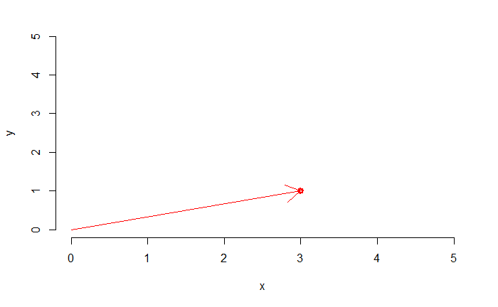

```r
plot(3,1, xlim=c(0,5), ylim=c(0,5), xlab="x", ylab="y", lwd=3, ,col='red', bty='n')
# plot(x, y, limite de x, limite de x, label x, label x, line with, color, box type )
arrows(0,0,3,1,col='red')
```

```r
# arrows(from x,from y, to x, to y, color, lty, lwd)
```

#### 2. Ejecute el siguiente código y explique según lo estudiado en clase: ¿Cuáles fueron los dos vectores base para diseñar la figura?, ¿Qué significa el vector de color verde?

```r
plot(3,1, xlim=c(0,5), ylim=c(0,5), xlab="x", ylab="y", lwd=3, ,col='red'
, bty='n')
arrows(0,0,3,1,col='red')
```

```r
points(1,3,lwd=3,col='blue')
arrows(0,0,1,3,col='blue')
```

```r
points(4,4,lwd=3,col='green')
arrows(0,0,4,4,col='green')
```

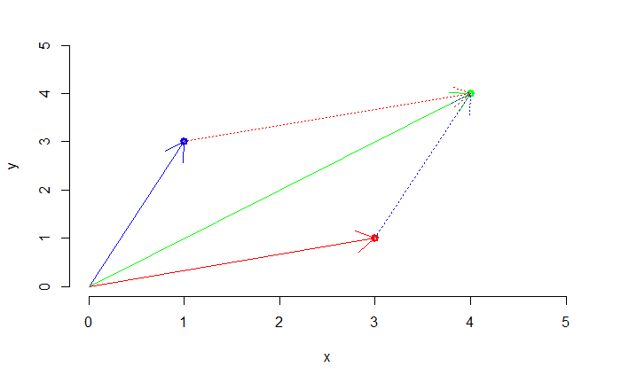

```r
arrows(1,3,4,4,col='red',lty=3)
arrows(3,1,4,4,col='blue',lty=3)
```

**Respuesta:** Los vectores utilizados para diseñar la figura fueron:  
u = (3, 1) v = (1, 3)

El vector de color verde representa la **suma** de ambos vectores.

#### Realice una modificación al Código, de manera que se en lugar de ilustrar la suma de vectores, se ilustre la resta de los vectores base.

```r
plot(3,1, xlim=c(0,5), ylim=c(0,5), xlab="x", ylab="y", lwd=3, ,col='red', bty='n')
arrows(0,0,3,1,col='red')
```

```r
points(1,3,lwd=3,col='blue')
arrows(0,0,1,3,col='blue')
```

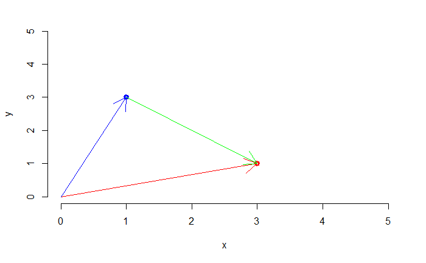

```r
arrows(1,3,3,1,col='green')
```

#### Además, complete la siguiente tabla, explicando la función de ciertas instrucciones del comando plot y arrows:

| Comando | Explicacion |
| --- | --- |
| xlim, ylim | Define los limites en los ejes “x” y “y” |
| xlab, ylab | Define las etiquetas en los ejes “x” y “y” |
| lwd | Define el ancho de la linea |
| lty | Define el tipo de linea |
| col | Define el color de la linea |
| bty | Define el estilo de la caja del grafico |